# 2019 Bacteria Beach Report

Connecticut Department of Energy and Environmental Protection

Report Created: July 2020

## 2019 Summary

[interactive chart not shown]

Start Date: **2019-05-20**  
End Date: **2019-08-28**

Total Samples Collected: **1287**

Number of Samples less than 10 cfu/100 mL (Non-Detects): **501**  
Number of Samples greater than 2000 cfu/100 mL: **16**

#### QC Checks

Milli-Q Samples : **0**  
Field Blank Samples: **0**  
(Both of these values should be zero, this means that all results were Non-Detects.)

Duplicates Calculation Check: **0**  
(If this value is not zero, then the script has found more than two samples from the same station/date.)

## 2019 Graphs

### Number of Closures

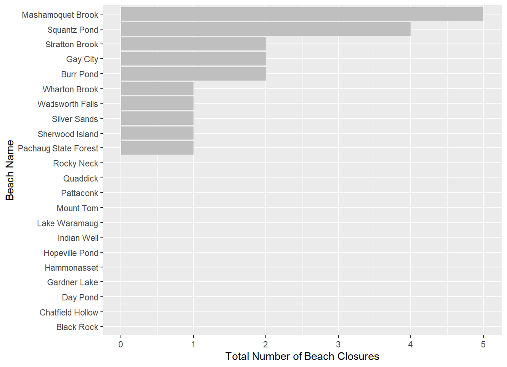

### Number of Days Closed

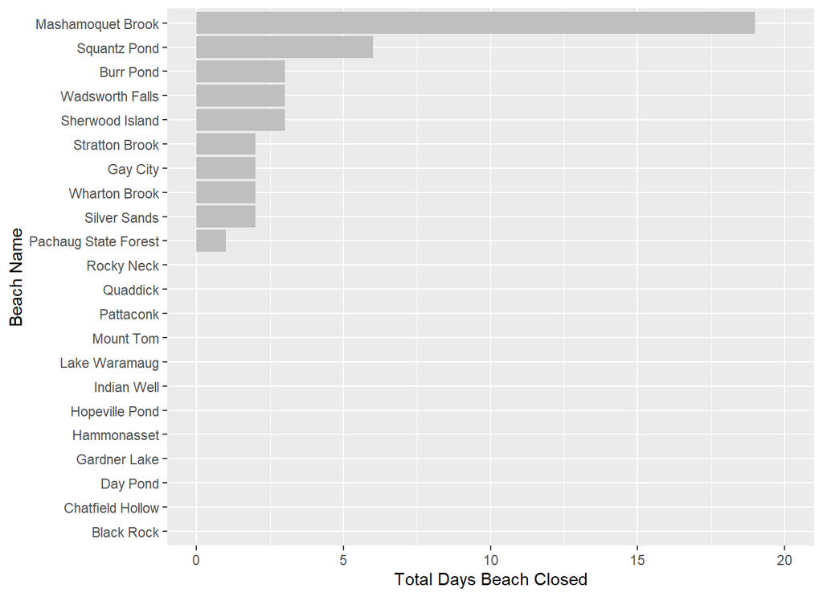

## QC Data

### Duplicates - Absolute Difference

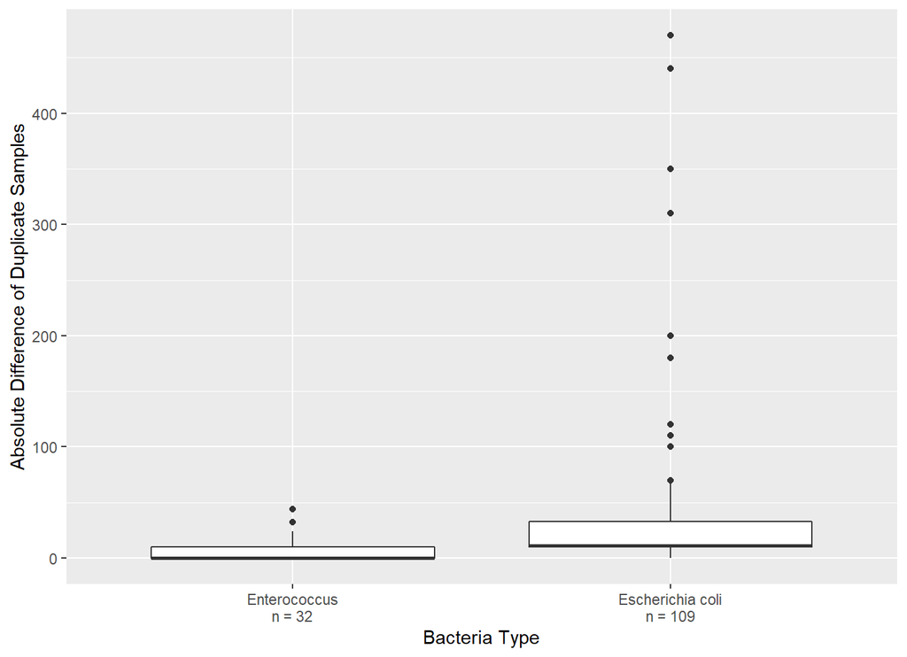

1. All ND values were calculated as 0 cfu/100 mL for this graphic
2. All values greater than 2000 were calculated as 2010 cfu/100 mL for this graphic

### Geometric Mean

| STA_SEQ | stateparkname | Location | geomean_low | geomean_high |
| --- | --- | --- | --- | --- |
| 14896 | Wharton Brook | WBK-3 at inlet Allen Brook Pond in Wharton Brook S.P. | 364 | 364 |
| 17604 | Rocky Neck | RNBB-2 at upper crabbing access on entry to parking area | 349 | 349 |
| 15906 | Gay City | GYC-3 at foot bridge on trail north of beach area | 180 | 180 |
| 15925 | Mashamoquet Brook | MMB-2 Right of Lifeguard Chair(s) | 179 | 179 |
| 15926 | Mashamoquet Brook | MMB-3 In brook upstream of Diversion to swimming pond | 170 | 170 |
| 14882 | Rocky Neck | RNBB-1 at RR crossing in park | 85 | 156 |
| 14730 | Rocky Neck | RN-156 at Rte.156 crossing | 145 | 145 |
| 15924 | Mashamoquet Brook | MMB-1 Left of Lifeguard Chair(s) | 98 | 132 |
| 17750 | Wadsworth Falls | WWF-IN Just downstream of inlet pipe | 96 | 96 |
| 15944 | Squantz Pond | SQPD-2 Right of Lifeguard Chair(s) | 17 | 72 |

[output cut: 53 more lines]

Geometric Mean Low Values  
1. All ND values were calculated as .001 cfu/100 mL for this graphic  
2. All values greater than 2000 were calculated as 2000 cfu/100 mL for this graphic

Geometric Mean High Values  
1. All ND values were calculated as 9.999 cfu/100 mL for this graphic  
2. All values greater than 2000 were calculated as 2000 cfu/100 mL for this graphic

## Closure Details

### Criteria Exceedence

|  | stateparkname | dateclosed | dateopened | totaldays | explanation |
| --- | --- | --- | --- | --- | --- |
| 1 | Stratton Brook | 2019-05-21 | 2019-05-22 | 1 | criteria exceedance |
| 2 | Mashamoquet Brook | 2019-05-21 | 2019-05-23 | 2 | criteria exceedance |
| 3 | Gay City | 2019-05-21 | 2019-05-22 | 1 | criteria exceedance |
| 4 | Mashamoquet Brook | 2019-06-12 | 2019-06-19 | 7 | criteria exceedance |
| 5 | Silver Sands | 2019-06-18 | 2019-06-20 | 2 | criteria exceedance |
| 6 | Squantz Pond | 2019-06-19 | 2019-06-20 | 1 | criteria exceedance |
| 7 | Burr Pond | 2019-06-26 | 2019-06-28 | 2 | criteria exceedance |
| 8 | Wharton Brook | 2019-07-09 | 2019-07-11 | 2 | criteria exceedance |
| 9 | Squantz Pond | 2019-07-10 | 2019-07-11 | 1 | criteria exceedance |
| 10 | Burr Pond | 2019-07-17 | 2019-07-18 | 1 | criteria exceedance |

[output cut: 9 more lines]

### Other Reason

|  | stateparkname | dateclosed | dateopened | totaldays | explanation |
| --- | --- | --- | --- | --- | --- |
| 1 | Sherwood Island | 2019-08-03 | 2019-08-06 | 3 | Admistrative Closure due to Potential contamination - due to sewage spill |

## Historical Data

### Closures

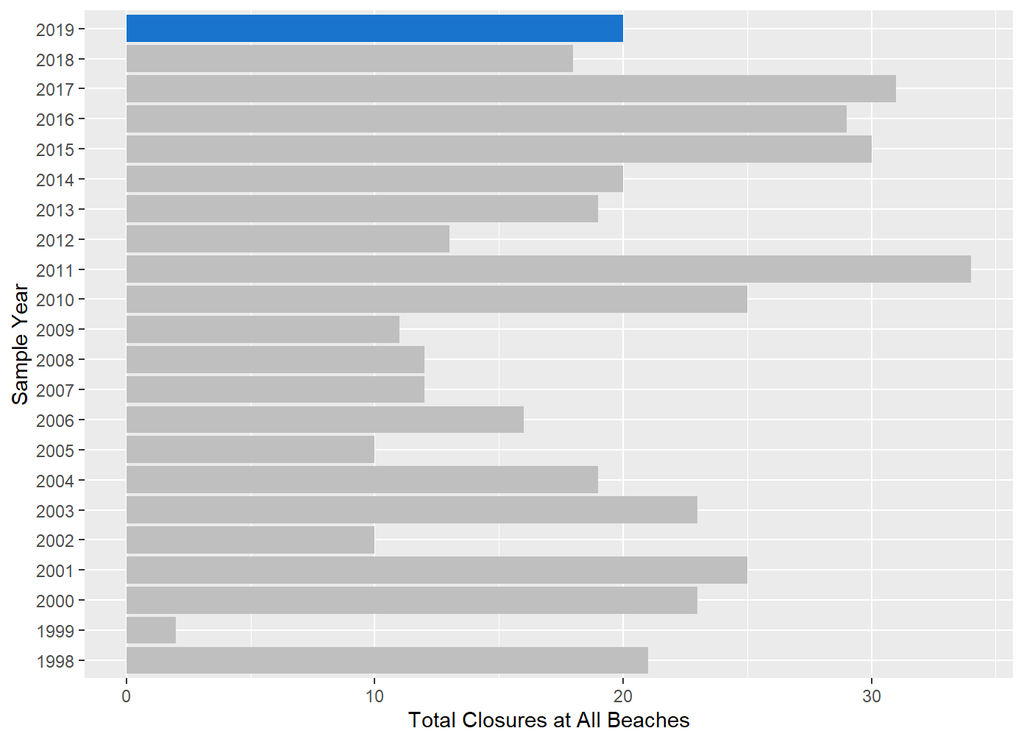

1. 2011 - Results impacted by Hurricane Irene (last week of beach season)
2. 2017 - Results impacted by change in sampling protocol  
   (samples collected Thursday/Friday led to an increase in weekend closures)

### Days Closed

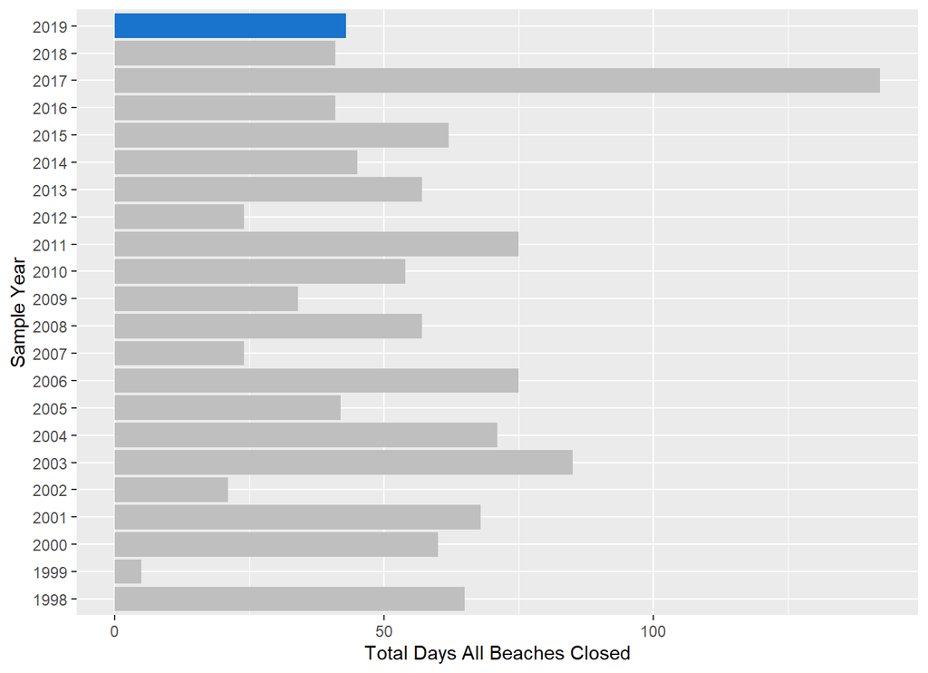

1. 2011 - Results impacted by Hurricane Irene (last week of beach season)
2. 2017 - Results impacted by change in sampling protocol  
   (samples collected Thursday/Friday led to an increase in weekend closures)

### Days Closed per Beach (Marine)

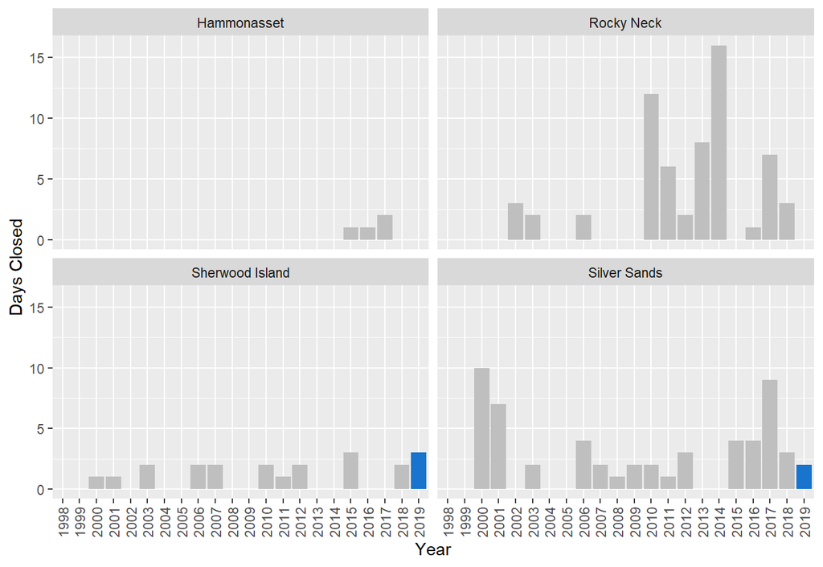

### Days Closed per Beach (Fresh)

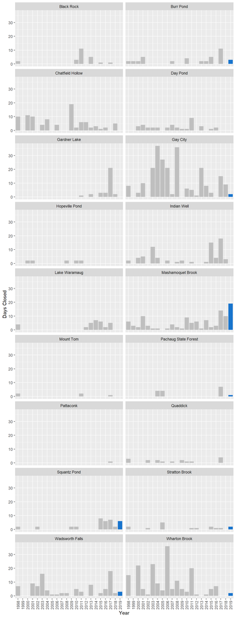

### Most Days Closed per Year (Marine)

| stateparkname | total_days | year |
| --- | --- | --- |
| Sherwood Island | 3 | 2019 |
| Rocky Neck | 3 | 2018 |
| Silver Sands | 9 | 2017 |
| Silver Sands | 4 | 2016 |
| Silver Sands | 4 | 2015 |
| Rocky Neck | 16 | 2014 |
| Rocky Neck | 8 | 2013 |
| Silver Sands | 3 | 2012 |
| Rocky Neck | 6 | 2011 |
| Rocky Neck | 12 | 2010 |

[output cut: 12 more lines]

### Most Days Closed per Year (Fresh)

| stateparkname | total_days | year |
| --- | --- | --- |
| Mashamoquet Brook | 19 | 2019 |
| Mashamoquet Brook | 10 | 2018 |
| Gardner Lake | 21 | 2017 |
| Wharton Brook | 7 | 2016 |
| Indian Well | 15 | 2015 |
| Gay City | 8 | 2014 |
| Gay City | 21 | 2013 |
| Chatfield Hollow | 6 | 2012 |
| Wharton Brook | 20 | 2011 |
| Mashamoquet Brook | 9 | 2010 |

[output cut: 12 more lines]